# SIM_Tugas_A_M0725088

Bryan

2026-04-14

## 1. Deskripsi Insight

Insight yang diambil dalam analisis ini adalah mengidentifikasi 10 produk dengan nilai marketing tertinggi serta melihat bagaimana hubungannya dengan profit yang dihasilkan. Tujuan dari analisis ini adalah untuk mengetahui apakah produk dengan biaya marketing tinggi juga memberikan profit yang tinggi, sehingga dapat menjadi dasar dalam pengambilan keputusan strategi pemasaran.

## 2. Import Data

```r
library(readxl)
library(dplyr)
```

```r
library(ggplot2)
data <- read_excel("C:/Users/LENOVO/Downloads/1. Tugas SIM 2025B - Coffee Chain Datasets.xlsx", sheet = "data")

head(data)
```

```
## # A tibble: 6 × 20
##   `Area Code` Date                Market  `Market Size` Product   `Product Line`
##         <dbl> <dttm>              <chr>   <chr>         <chr>     <chr>
## 1         719 2012-01-01 00:00:00 Central Major Market  Amaretto  Beans
## 2         970 2012-01-01 00:00:00 Central Major Market  Colombian Beans
## 3         970 2012-01-01 00:00:00 Central Major Market  Decaf Ir… Beans
## 4         303 2012-01-01 00:00:00 Central Major Market  Green Tea Leaves
## 5         303 2012-01-01 00:00:00 Central Major Market  Caffe Mo… Beans
## 6         720 2012-01-01 00:00:00 Central Major Market  Decaf Es… Beans
## # ℹ 14 more variables: `Product Type` <chr>, State <chr>, Type <chr>,
## #   `Budget COGS` <dbl>, `Budget Margin` <dbl>, `Budget Profit` <dbl>,
## #   `Budget Sales` <dbl>, COGS <dbl>, Inventory <dbl>, Margin <dbl>,
## #   Marketing <dbl>, Profit <dbl>, Sales <dbl>, `Total Expenses` <dbl>
```

## 3. Pengolahan Data

Mengelompokkan data berdasarkan produk dan menghitung total marketing serta profit.

```r
top10 <- data %>%
  group_by(Product) %>%
  summarise(
    Marketing = sum(Marketing),
    Profit = sum(Profit)
  ) %>%
  arrange(desc(Marketing)) %>%
  slice(1:10)

top10
```

```
## # A tibble: 10 × 3
##    Product           Marketing Profit
##    <chr>                 <dbl>  <dbl>
##  1 Caffe Mocha           19686  17678
##  2 Colombian             17346  55804
##  3 Lemon                 15880  29869
##  4 Chamomile             12166  27231
##  5 Decaf Irish Cream     11362  13989
##  6 Decaf Espresso        10112  29502
##  7 Earl Grey              9846  24164
##  8 Darjeeling             9766  29053
##  9 Green Tea              7126   -231
## 10 Mint                   6108   6154
```

## 4. Visualisasi Data

Top 10 Marketing

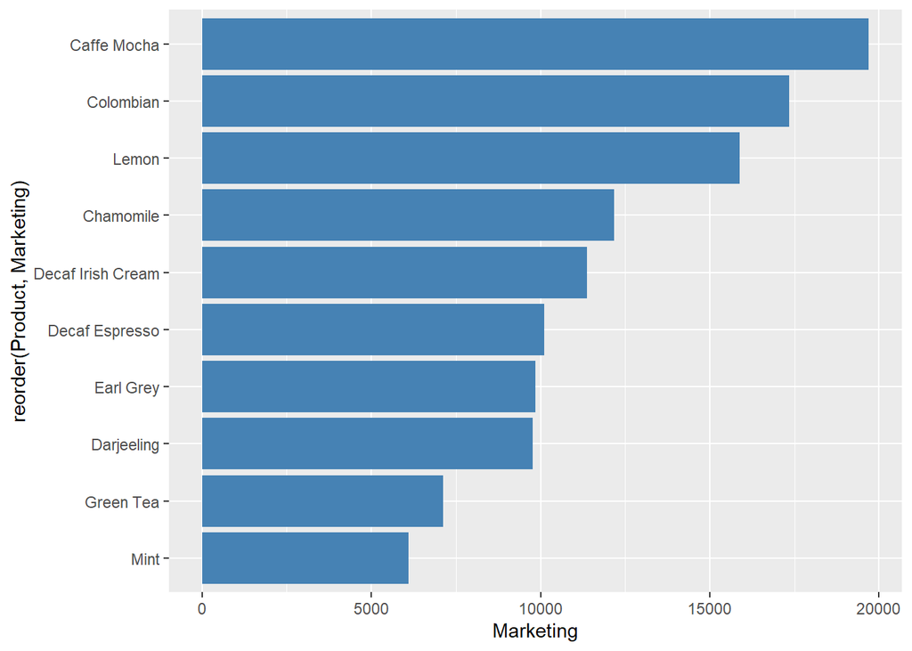

```r
ggplot(top10, aes(x = reorder(Product, Marketing), y = Marketing)) +
  geom_bar(stat = "identity", fill = "steelblue") +
  coord_flip()
```

```r
labs(
    title = "Top 10 Produk dengan Marketing Tertinggi",
    x = "Produk",
    y = "Marketing"
  )
```

```
## <ggplot2::labels> List of 3
##  $ x    : chr "Produk"
##  $ y    : chr "Marketing"
##  $ title: chr "Top 10 Produk dengan Marketing Tertinggi"
```

## 5. Hubungan Marketing Dan Profit

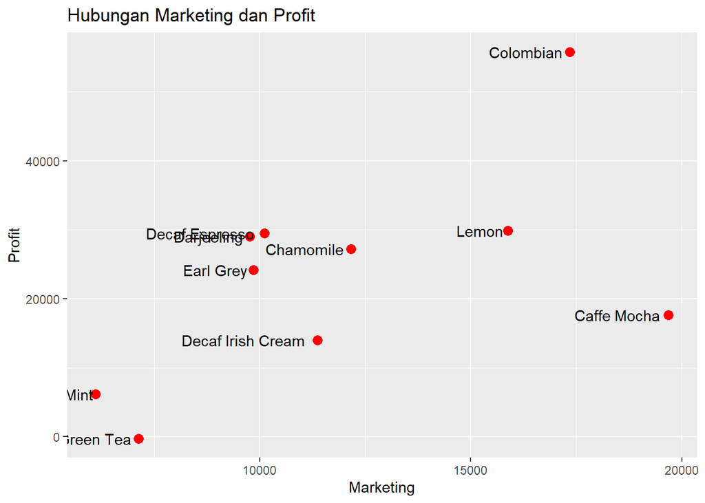

```r
ggplot(top10, aes(x = Marketing, y = Profit, label = Product)) +
  geom_point(color = "red", size = 3) +
  geom_text(hjust = 1.1) +
  labs(
    title = "Hubungan Marketing dan Profit",
    x = "Marketing",
    y = "Profit"
  )
```

## 6. Analisis Statistik

```r
correlation <- cor(top10$Marketing, top10$Profit)
correlation
```

```
## [1] 0.5736779
```

## 7. Interpretasi

Berdasarkan visualisasi, terlihat bahwa produk dengan nilai marketing tertinggi tidak selalu menghasilkan profit tertinggi. Hal ini menunjukkan bahwa pengeluaran marketing yang besar belum tentu efisien dalam meningkatkan keuntungan.

## 8. Kesimpulan

Dari analisis yang dilakukan, dapat disimpulkan bahwa terdapat variasi antara biaya marketing dan profit yang dihasilkan. Tidak semua produk dengan marketing tinggi memberikan profit yang optimal. Oleh karena itu, perusahaan perlu melakukan evaluasi strategi pemasaran agar dapat meningkatkan efektivitas penggunaan anggaran marketing.